# Critical IS Research Seminar

## Critical IS Research Seminar (Galway, 15 November 2023)

To Reveal and Provoke: *An Open Invitation to Critical Information Systems Research*

Blair Wang  
University of Galway, Ireland  
`blair.wang@universityofgalway.ie`

Disciple of Business Information Systems Seminar Series  
15 November 2023

—

You can get a copy of this notebook at www.blair.wang/cisr (one-file webpage).

Generated using [Quarto](https://quarto.org/).

## 1. What is critical IS research?

### What is research in general?

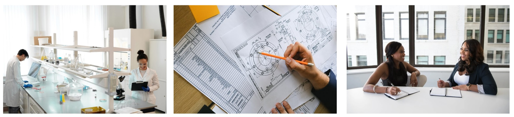

Image sources: pexels.com #4031687, #5324968, #1181605

- **“How the world works”?** (classic “science” as in Wissenschaft / Naturwissenschaft)
- **“How to make something new”?** (R&D — research & development)
- **“How people think/behave”?** (social sciences)

### A critical perspective in IS?

> *Critical IS studies aim at **revealing**, criticizing and explaining how the development and use of IS in organizations and society **in the pursuit of efficiency, rationalization and progress** also increase social control and domination, with potential **detrimental consequences** for some stakeholders and society as a whole. Being ‘critical’ in IS research also means subscribing to a much broader historical, social and political view of the IS discipline and the role of IS across all institutional levels of society. Critical research draws attention to the ways in which economic and **managerial interests, ideologies and discourses**, assisted by educational and research funding institutions, shape and construct IS research.*

(Cecez-Kecmanovic, Klein, & Brooke, 2008, p. 123, emphasis added)

- **Revealing** → *‘explaining’*, *‘criticizing’*
- **Provoking** → *‘draws attention’*

**Note**

- **“To reveal is to critique”** (Doolin & Lowe, 2002)
- More about **understanding (the extent of) the problem** rather than already trying to develop the solution. In fact there’s a concept in critical IS research called **digital solutionism** which critiques premature or naive solutions (Rowe, Ngwenyama, & Richet, 2020a).
- We are implicitly **rejecting technological determinism** in favour of something more like social constructivism or even free will (Kreps & Rowe, 2021).

### Two mental images: “Calling BS”, “Black Mirror”

[figure not shown]

Image sources: Bergstrom & West (2020), Netflix

1. **“Calling BS”** (Bergstrom & West, 2020; Christensen, Kärreman, & Rasche, 2019), e.g., *“calling BS on ChatGPT”* (Sundar & Liao, 2023).
2. Two Netflix shows — *Black Mirror* (2011—2023), *Love Death + Robots* ❤️❌🤖 (2019—2022)

### Example: Discussion around the human labour behind AI

[figure not shown]

MIT Technology Review [article](https://www.technologyreview.com/2023/06/13/1074560/we-are-all-ais-free-data-workers/), 13 June 2023

### Example: Schulzke (2014) on virtual worlds

> *While artificial worlds have enormous potential to facilitate communication, transcend spatial boundaries, promote free expression, and protect marginalized groups, **the utopian promise of these worlds is undermined by their mirroring of real-world market systems, the exploitation of labor, and blurring the line between entertainment and work.***

(Schulzke, 2014, p. 20)

**Note**

- **“Investigation: How Roblox Is Exploiting Young Game Developers”** by More People Make Games (2,282,376 views, 19 Aug 2021) — https://www.youtube.com/watch?v=_gXlauRB1EQ
- **“Roblox Pressured Us to Delete Our Video. So We Dug Deeper.”** by More People Make Games (7,222,609 views, 13 Dec 2021) — https://www.youtube.com/watch?v=vTMF6xEiAaY
- **“Roblox Is Exploiting Kids. We Talked To Some Of Them.”** by More Perfect Union (168,980 views, 7 Sept 2023) — https://www.youtube.com/watch?v=n6PYj93SGxc

### Myers and Klein (2011)

[figure not shown]

Prominent work by Michael D. Myers & Klein (2011).

**Three elements of critical research (insight, critique, transformation)**

Definitions taken from Michael D. Myers & Klein (2011), p. 24; adapted from Alvesson & Deetz (2000).

- **Insight:** *“This element is concerned with interpretation and gaining insight. Insight can be gained in various ways, e.g., using critical hermeneutics and the archaeology of knowledge, or the concepts of social reproduction via the mechanisms associated with symbolic capital.”*
- **Critique:** *“This element is concerned with critique, the genealogy of knowledge, and the social practices of control and reproduction. This element goes beyond interpretation to focus the researcher on the power structures that lie behind accepted interpretations.”*
- **Transformation:** *“This element is concerned with suggesting improvements to the conditions of human existence, existing social arrangements, and social theories. Theories are not the primary driver for changes, but potentially fallible lenses through which we see the world. The ultimate arbiters of the desirability of changes are those affected by them.”*

### Similar and not-so-similar areas of research

**Very similar** ✅

- Critical Theory (Bronner, 2011)
- Critical Management Studies (Alvesson & Willmott, 1992), to which IS researchers contributed (Lyytinen, 1992)
- Science and Technology Studies (Hackett, Amsterdamska, Lynch, & Wajcman, 2008)

**Historical development of critical IS research 1991—2011**

- Orlikowski & Baroudi (1991)
- Ngwenyama (1991)
- Alvesson & Willmott (1992)
- Lyytinen (1992)
- Hirschheim, Klein, & Lyytinen (1996)
- Michael D. Myers & Young (1997)
- Alvesson & Deetz (2000)
- Brooke (2002), Cecez-Kecmanovic, Janson, & Brown (2002) (special issue in *JIT*)
- McGrath (2005)
- Richardson & Robinson (2007)
- Cecez-Kecmanovic et al. (2008)
- Michael D. Myers & Klein (2011)

**Somewhat related** 💡

*Typically, but not necessarily, more focused on rules/solutions:*

- IS Ethics research (see also Stahl, 2008)
- Responsible Technology research, ‘dark side’ IS research (see also Mikalef, Conboy, Lundström, & Popovič, 2022)

*Typically, but not necessarily, more descriptive and neutral:*

- Institutional Theory (see note)
- Critical Literature Review (refer to Paré, Trudel, Jaana, & Kitsiou, 2015)
- Exemplar ‘critical’ in both senses: Avgerou (2008)

**Institutional Theory and Critical Research — very hotly debated!**

- *“Can Institutional Theory Be Critical?”* (Suddaby, 2014)
- *“Why Institutional Theory Cannot Be Critical”* (Willmott, 2014)
- *“Challenging Institutional Theory’s Critical Credentials”* (Munir, 2019)
- *“Hasn’t Institutional Theory Always Been Critical?!”* (Drori, 2019)

**Not really similar** ❌

- Critical Race Theory — typically more contentious claims
- Critical Realism — entirely different focus [refer to https://www.jstor.org/stable/43826000]

## 2. “Calling BS”, based on grand theorists

### Historic n°1 — Kant (Enlightenment, Emancipation)

RESEARCH HOW EMANCIPATION IS DONE

- Broad literature review of emancipation in IS by https://aisel.aisnet.org/cgi/viewcontent.cgi?article=1829&context=hicss-54
- (ALT. “EMPOWERMENT V. MARGINALIZATION”, “EMPOWERMENT V CONTROL”) Connolly, Sanchez, Compeau, & Tacco (2023) , Deng, Joshi, & Galliers (2016), Duane & Finnegan (2003) 🇮🇪 , Leong, Tan, Tan, & Faisal (2022)

RESEARCH THAT EMANCIPATES

- Stahl, Tremblay, & LeRouge (2011)

BUILD THAT EMANCIPATES

- Emancipatory principles in participatory design (Hirschheim & Klein, 1994), e.g., **workplace democracy** in participatory design (Kautz, 2011)
- “Effective Technical and Human Implementation of Computer Systems (ETHICS)” approach to participatory design (Mumford, 1993, 1995)
- “Emancipatory design science” (Heusinger, 2014; Kane, Young, Majchrzak, & Ransbotham, 2021; Young & Zhu, 2022)

### Historic n°2 — Marx (Alienation, Labour Process)

Alienation:

- Rowe, Ngwenyama, & Richet (2020b)
- Greenbaum (1996)

Labour Process Analysis:

### Historic n°3 — Early Frankfurt School (Adorno, Horkheimer, Marcuse)

- Disillusioned with fascism (Nazi Germany), consumerism (America), and communism (USSR)
- Cynical about their present, utopian about the future (e.g., Marcuse’s writing on art)

> “The optimistic, some would say utopian, nature of these narratives and their ‘totalizing’ tendencies (Alvesson & Willmott, 1992) may be understood as a response to a Nazi regime, from which members of the Frankfurt School fled into exile in the United States in the mid-1930s (Burrell, 1994).”

(McGrath, 2005, p. 89)

### Classic n°1 — Bourdieu

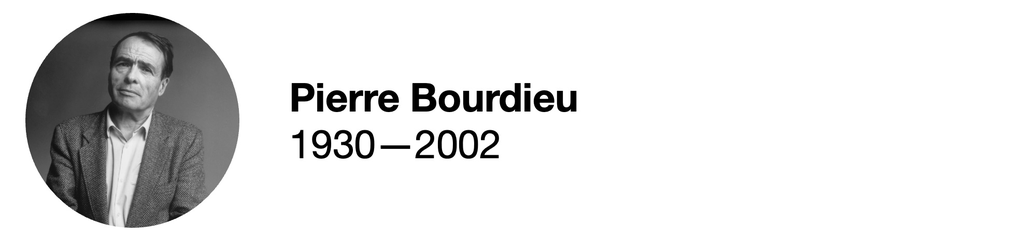

Image source: [New York Times](https://www.nytimes.com/2017/07/18/opinion/inequality-pierre-bourdieu.html)

Field, habitus and theory of practice

- Vaidya & Myers (2020)

Social stratification / cultural production

- Levina & Arriaga (2014)

Economic capital, social capital, cultural capital, symbolic capital

- Karahanna, Chen, Liu, & Serrano (2019)
- Newman, Browne-Yung, Raghavendra, Wood, & Grace (2017)

### Classic n°2 — Foucault

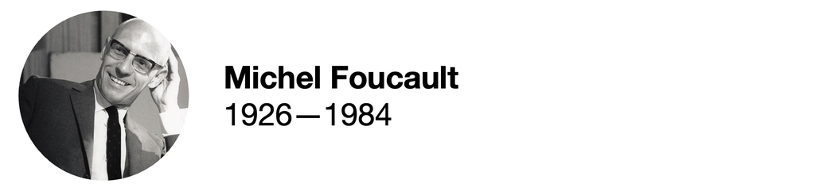

Image source: [contemporarythinkers.org](https://contemporarythinkers.org/michel-foucault/biography/)

- Archaelogy/geneaology
  - ‘The birth of …’ (Nyman, Bødker, & Jensen, 2023; Nyman, Bødker, Jensen, & Gudmand-Høyer, 2021)
- Panopticon
  - Jonsson (2006)
  - Wicker & Ghosh (2020)

### Classic n°3 — Habermas

TRIAGE: Cecez-Kecmanovic, D. (2001) Critical information systems research: a Habermasian perspective. In: Proceedings of the 9th European Conference on Information Systems, S. Smithson, J. Gricar, M. Podlogar & S. Avgerinou (eds), pp. 253–263. Moderna Organizacija, Kranj, Slovenia

TRIAGE: Lyytinen, K. & Hirschheim, R. (1988) Information systems as rational discourse: an application of Habermas’ the- ory of communicative action. Scandinavian Journal of Management, 4, 19–30.

TRIAGE: https://www.tandfonline.com/doi/abs/10.1080/01972240802587562 (Nick Berente)

Lifeworld vs. systems

Different kinds of action/rationality: Instrumental, strategic and communicative

**Summary of the different kinds of action/rationality**

### Postcolonial Theorists

See also general reading by Masiero (2022), Tsibolane & Brown (2016).

Said, Spivak, Bhabha

From Masiero 2022:

- Addo (2017)
- Lin, Kuo, & Myers (2015)
- Masiero (2018)

### Surveillance Capitalism (Zuboff, 2015), Platform Capitalism (Srnicek, 2017), Digital Serfdom (Nycyk, 2020)

### STS n°1 — Actor Network Theory

- Doolin & Lowe (2002)

### STS n°2 — Critical Theory of Technology (Feenberg)

### STS n°3 — Fungible Grid Temporality (Wajcman)

### STS n°4 — Future Studies and sociotechnical imaginings

## 3. “Calling BS”, based on broad ideas

### Critical Hermeneutics

Hermeneutic circle (Gadamer, 1960)

Critical hermeneutics is doing that with a critical approach (Kinsella, 2006), **“being critical about interpreting information technology”** (Doolin, 1998, p. 302)

- Young & Wigdor (2021)
- Saghafi & Wang (2017)

### Critical Discourse Analysis

- Adam (2002)
- Cukier, Ngwenyama, Bauer, & Middleton (2009)
- Hur, Cousins, & Stahl (2019)

### Feminist Analysis

Broadly extends to issues of gender, sexuality, LGBTQ+, etc.

Methods paper: Howcroft & Trauth (2008)

IT workforce:

- Craig (2015)
- E. M. Trauth & Howcroft (2006)
- E. Trauth & Connolly (2021) 🇮🇪

Gendered assessment of IT artifacts themselves:

- L. Wang (2020)
- Lingel (2021)
- Gengler, Wedel, Wudel, & Laumer (2023)

Feminist critique of IS research:

- Curto-Millet, Lindman, & Selander (2022)

### Narrative Analysis and Dramaturgical Analysis

Narrative, i.e., stories:

- Icarus (Drummond, 2008; Pinsonneault & Rivard, 1998)
- Prometheus (Conboy, 2019, 2021; Conboy, Gleasure, & Morgan, 2022)
- Golem and Leviathan (Popa, 2022)

Dramaturgical, i.e., performances:

### Paradox

Methods paper: B. Wang, Ciriello, & Mathiassen (2023)

Examples of work:

- Howcroft & Wilson (2003)
- Elmes, Strong, & Volkoff (2005)

### Dialectics

Methods paper: Ciriello & Mathiassen (2022)

Examples:

- Greenhill & Wilson (2006)

### Inductive approaches

- Algorithm abstinence (Hannon, 2022)
- ‘Stockholm syndrome’ on social media (Rinaudo, 2022)
- Algorithmic audiencing (Riemer & Peter, 2021)

“Beyond the Panopticon”

- Leclercq-Vandelannoitte, Isaac, & Kalika (2014) on “beyond the panopticon”
- Panopticon vs. exile (Hafermalz, 2021)
- Heautopticon (De Moya & Pallud, 2020)

## 4. Proposed Next Steps

**What is your passion?**

**Excellent podcasts**

- Philosophize This
- 99% Invisible

## 5. References

Adam, A. (2002). Exploring the gender question in critical information systems. *Journal of Information Technology*, *17*(2), 59–67. doi: 10.1080/02683960210145959

Addo, A. (2017). Subalternity in information systems in developing countries. In *Information and communication technologies for development* (pp. 573–592). Springer. doi: 10.1007/978-3-319-59111-7_47

Alvesson, M., & Deetz, S. (2000). *Doing critical management research*. Sage.

Alvesson, M., & Willmott, H. (1992). On the idea of emancipation in management and organization studies. *The Academy of Management Review*, *17*(3), 432–464. doi: 10.2307/258718

Avgerou, C. (2008). Information systems in developing countries: A critical research review. *Journal of Information Technology*, *23*(3), 133–146. doi: 10.1057/palgrave.jit.2000136

Bergstrom, C. T., & West, J. D. (2020). *Calling bullshit: The art of skepticism in a data-driven world*. Random House.

Bronner, S. E. (2011). *Critical theory: A very short introduction*. Oxford University Press.

Brooke, C. (2002). What does it mean to be “critical” in IS research? *Journal of Information Technology*, *17*(2), 49–57. doi: 10.1080/02683960210164336

Burrell, G. (1994). Modernism, postmodernism and organizational analysis 4: The contribution of Jürgen Habermas. *Organization Studies*, *15*(1), 1–19. doi: 10.1177/017084069401500101

Cecez-Kecmanovic, D., Janson, M., & Brown, A. (2002). The rationality framework for a critical study of information systems. *Journal of Information Technology*, *17*(4), 215–227. doi: 10.1080/0268396022000017752

Cecez-Kecmanovic, D., Klein, H. K., & Brooke, C. (2008). Exploring the critical agenda in information systems research. *Information Systems Journal*, *18*(2), 123–135. doi: 10.1111/j.1365-2575.2008.00295.x

Christensen, L. T., Kärreman, D., & Rasche, A. (2019). Bullshit and organization studies. *Organization Studies*, *40*(10), 1587–1600. doi: 10.1177/0170840618820072

Ciriello, R. F., & Mathiassen, L. (2022). Dialectical inquiry in information systems research: A synthesis of principles. In *Proceedings of the international conference on information systems*.

Conboy, K. (2019). Being Promethean. *European Journal of Information Systems*, *28*(2), 119–125. doi: 10.1080/0960085x.2019.1586189

Conboy, K. (2021). Enabling Promethean leaps: An examination of storytelling techniques in information systems development. *Communications of the Association for Information Systems*, *48*(1), 333–351. doi: 10.17705/1cais.04835

Conboy, K., Gleasure, R., & Morgan, L. (2022). When crowds play god: A Promethean perspective on crowdfunding. *European Journal of Information Systems*, *31*(2), 207–226. doi: 10.1080/0960085x.2020.1860655

Connolly, R., Sanchez, O. P., Compeau, D., & Tacco, F. (2023). Understanding engagement in online health communities: A trust-based perspective. *Journal of the Association for Information Systems*, *24*(2), 345–378. doi: 10.17705/1jais.00785

Craig, A. (2015). Theorising about gender and computing interventions through an evaluation framework. *Information Systems Journal*, *26*(6), 585–611. doi: 10.1111/isj.12072

Cukier, W., Ngwenyama, O., Bauer, R., & Middleton, C. (2009). A critical analysis of media discourse on information technology: Preliminary results of a proposed method for critical discourse analysis. *Information Systems Journal*, *19*(2), 175–196. doi: 10.1111/j.1365-2575.2008.00296.x

Curto-Millet, D., Lindman, J., & Selander, L. (2022). Subaltern studies: Advancing critical theory in ICT4D. In *Proceedings of the americas conference on information systems*.

De Moya, J.-F., & Pallud, J. (2020). From panopticon to heautopticon: A new form of surveillance introduced by quantified-self practices. *Information Systems Journal*, *30*(6), 940–976. doi: 10.1111/isj.12284

Deng, X., Joshi, K. D., & Galliers, R. D. (2016). The duality of empowerment and marginalization in microtask crowdsourcing. *MIS Quarterly*, *40*(2), 279–302.

Doolin, B. (1998). Information technology as disciplinary technology: Being critical in interpretive research on information systems. *Journal of Information Technology*, *13*(4), 301–311. doi: 10.1057/jit.1998.8

Doolin, B., & Lowe, A. (2002). To reveal is to critique: Actor-network theory and critical information systems research. *Journal of Information Technology*, *17*(2), 69–78. doi: 10.1080/02683960210145986

Drori, G. S. (2019). Hasn’t institutional theory always been critical?! *Organization Theory*, *1*(1), 263178771988798. doi: 10.1177/2631787719887982

Drummond, H. (2008). The Icarus paradox: An analysis of a totally destructive system. *Journal of Information Technology*, *23*(3), 176–184. doi: 10.1057/palgrave.jit.2000119

Duane, A., & Finnegan, P. (2003). Managing empowerment and control in an intranet environment. *Information Systems Journal*, *13*(2), 133–158. doi: 10.1046/j.1365-2575.2003.00148.x

Elmes, M. B., Strong, D. M., & Volkoff, O. (2005). Panoptic empowerment and reflective conformity in enterprise systems-enabled organizations. *Information and Organization*, *15*(1), 1–37. doi: 10.1016/j.infoandorg.2004.12.001

Gadamer, H.-G. (1960). *Truth and method* (J. Weinsheimer & D. G. Marshall, Trans.). New York, USA: Continuum.

Gengler, E. J., Wedel, M., Wudel, A., & Laumer, S. (2023). Subaltern studies: Advancing critical theory in ICT4D. In *Proceedings of the international conference on wirtschaftsinformatik*.

Greenbaum, J. (1996). Labor is more than work: Using labor analysis to study use situations and jobs. *Scandinavian Journal of Information Systems*, *8*(2).

Greenhill, A., & Fletcher, G. (2013). Laboring online: Are there “new” labor processes in virtual game worlds? *Journal of the Association for Information Systems*, *14*(11), 672–693. doi: 10.17705/1jais.00346

Greenhill, A., & Wilson, M. (2006). Haven or hell? Telework, flexibility and family in the e-society: A marxist analysis. *European Journal of Information Systems*, *15*(4), 379–388. doi: 10.1057/palgrave.ejis.3000632

Habermas, J. (1984). *The theory of communicative action volume 1: Reason and the rationalization of society* (T. McCarthy, Trans.). Apple Books.

Hackett, E. J., Amsterdamska, O., Lynch, M., & Wajcman, J. (2008). *The handbook of science and technology studies* (3rd ed.). MIT Press.

Hafermalz, E. (2021). Out of the panopticon and into exile: Visibility and control in distributed new culture organizations. *Organization Studies*, *42*(5), 697–717. doi: 10.1177/0170840620909962

Haj-Bolouri, A., Kruse Chandra, L., Iivari, J., & Flensburg, P. (2016). How Habermas’ philosophy can inspire the design of information systems: The case of designing an open learning platform for social integration. In *Proceedings of the Information Systems Research Seminar in Scandinavia*. Ljungskile, Sweden. Retrieved from https://aisel.aisnet.org/iris2016/2/

Hannon, G., Oliver. (2022). Aversion vs. Abstinence: Conceptual distinctions for the receptivity toward algorithmic decision-making systems within value-laden contexts. In *Proceedings of the Australasian Conference on Information Systems*. Melbourne, Australia.

Heusinger, J. M. (2014). On the “impossibility” of critical and emancipatory design science research. In *Enterprise information systems* (pp. 331–348). Springer International Publishing. doi: 10.1007/978-3-319-09492-2_20

Hirschheim, R., & Klein, H. K. (1994). Realizing emancipatory principles in information systems development: The case for ETHICS. *MIS Quarterly*, *18*(1), 83. doi: 10.2307/249611

Hirschheim, R., Klein, H. K., & Lyytinen, K. (1996). Exploring the intellectual structures of information systems development: A social action theoretic analysis. *Accounting, Management and Information Technologies*, *6*(1-2), 1–64. doi: 10.1016/0959-8022(96)00004-5

Howcroft, D., & Trauth, E. M. (2008). The implications of a critical agenda in gender and IS research. *Information Systems Journal*, *18*(2), 185–202. doi: 10.1111/j.1365-2575.2008.00294.x

Howcroft, D., & Wilson, M. (2003). Paradoxes of participatory practices: The janus role of the systems developer. *Information and Organization*, *13*(1), 1–24. doi: 10.1016/s1471-7727(02)00023-4

Hur, I., Cousins, K. C., & Stahl, B. C. (2019). A critical perspective of engagement in online health communities. *European Journal of Information Systems*, *28*(5), 523–548. doi: 10.1080/0960085x.2019.1620477

Jonsson, K. (2006). The embedded panopticon: Visibility issues of remote diagnostics surveillance. *Scandinavian Journal of Information Systems*, *18*(2).

Kane, G. C., Young, A. G., Majchrzak, A., & Ransbotham, S. (2021). Avoiding an oppressive future of machine learning: A design theory for emancipatory assistants. *MIS Quarterly*, *45*(1), 371–396. doi: 10.25300/misq/2021/1578

Karahanna, E., Chen, A., Liu, Q. B., & Serrano, C. (2019). Capitalizing on health information technology to enable advantage in u.s. hospitals. *MIS Quarterly*, *43*(1), 113–140. doi: 10.25300/misq/2019/12743

Kautz, K. (2011). Investigating the design process: Participatory design in agile software development. *Information Technology & People*, *24*(3), 217–235. doi: 10.1108/09593841111158356

Kinsella, E. A. (2006). Hermeneutics and critical hermeneutics: Exploring possibilities within the art of interpretation. *Forum Qualitative Sozialforschung*, *7*(3). doi: 10.17169/fqs-7.3.145

Kreps, D., & Rowe, F. (2021). Free will in philosophy and in IS research: Where do we stand and where do we want to be? In *Proceedings of the international conference on information systems*. Austin, USA.

Leclercq-Vandelannoitte, A., Isaac, H., & Kalika, M. (2014). Mobile information systems and organisational control: Beyond the panopticon metaphor? *European Journal of Information Systems*, *23*(5), 543–557. doi: 10.1057/ejis.2014.11

Leong, C., Tan, F. T. C., Tan, B., & Faisal, F. (2022). The emancipatory potential of digital entrepreneurship: A study of financial technology-driven inclusive growth. *Information & Management*, *59*(3), 103384. doi: 10.1016/j.im.2020.103384

Levina, N., & Arriaga, M. (2014). Distinction and status production on user-generated content platforms: Using Bourdieu’s theory of cultural production to understand social dynamics in online fields. *Information Systems Research*, *25*(3), 468–488. doi: 10.1287/isre.2014.0535

Lin, C. I. C., Kuo, F.-Y., & Myers, M. D. (2015). Extending ICT4D studies: The value of critical research. *MIS Quarterly*, *39*(3), 697–712. doi: 10.25300/misq/2015/39.3.09

Lingel, J. (2021). A queer and feminist defense of being anonymous online. In *Proceedings of the hawaii international conference on system sciences*. Hawaii, USA.

Lyytinen, K. (1992). Information systems and critical theory. In M. Alvesson & H. Willmott (Eds.), *Critical management studies* (pp. 159–180). SAGE.

Masiero, S. (2018). Subaltern studies: Advancing critical theory in ICT4D. In *Proceedings of the european conference on information systems*.

Masiero, S. (2022). Decolonising critical information systems research: A subaltern approach. *Information Systems Journal*, *33*(2), 299–323. doi: 10.1111/isj.12401

McGrath, K. (2005). Doing critical research in information systems: A case of theory and practice not informing each other. *Information Systems Journal*, *15*(2), 85–101. doi: 10.1111/j.1365-2575.2005.00187.x

Mikalef, P., Conboy, K., Lundström, J. E., & Popovič, A. (2022). Thinking responsibly about responsible AI and “the dark side” of AI. *European Journal of Information Systems*, *31*(3), 257–268. doi: 10.1080/0960085x.2022.2026621

Mumford, E. (1993). The participation of users in systems design: An account of the origin, evolution, and use of the ETHICS method. In *Participatory design* (pp. 257–270). CRC Press. doi: 10.1201/9780203744338-12

Mumford, E. (1995). *Effective systems design and requirements analysis*. Macmillan. doi: 10.1007/978-1-349-13774-9

Munir, K. A. (2019). Challenging institutional theory’s critical credentials. *Organization Theory*, *1*(1). doi: 10.1177/2631787719887975

Myers, Michael D., & Klein, H. K. (2011). A set of principles for conducting critical research in information systems. *MIS Quarterly*, 17–36. doi: 10.2307/23043487

Myers, Michael D., & Young, L. W. (1997). Hidden agendas, power and managerial assumptions in information systems development. *Information Technology & People*, *10*(3), 224–240. doi: 10.1108/09593849710178225

Newman, L., Browne-Yung, K., Raghavendra, P., Wood, D., & Grace, E. (2017). Applying a critical approach to investigate barriers to digital inclusion and online social networking among young people with disabilities. *Information Systems Journal*, *27*(5), 559–588. doi: 10.1111/isj.12106

Ngwenyama, O. K. (1991). From data serfdom to data ownership: An alternative futures view of personal data as property rights. In *Information systems research: Contemporary approaches and emergent traditions* (pp. 267–280). North-Holland.

Nycyk, M. (2020). From data serfdom to data ownership: An alternative futures view of personal data as property rights. *Journal of Futures Studies*, *24*(4), 25–34. doi: 10.6531/JFS.202006_24(4).0003

Nyman, S., Bødker, M., & Jensen, T. B. (2023). Reforming work patterns or negotiating workloads? Exploring alternative pathways for digital productivity assistants through a problematization lens. *Journal of Information Technology*. doi: 10.1177/02683962231181602

Nyman, S., Bødker, M., Jensen, T., & Gudmand-Høyer, M. (2021). Exploring the archive: A problematization lens for conducting critical IS research. In *Proceedings of the international conference on information systems*. Austin, USA.

Orlikowski, W. J., & Baroudi, J. J. (1991). Studying information technology in organizations: Research approaches and assumptions. *Information Systems Research*, *2*(1), 1–28. doi: 10.1287/isre.2.1.1

Paré, G., Trudel, M.-C., Jaana, M., & Kitsiou, S. (2015). Synthesizing information systems knowledge: A typology of literature reviews. *Information & Management*, *52*(2), 183–199. doi: 10.1016/j.im.2014.08.008

Pinsonneault, A., & Rivard, S. (1998). Information technology and the nature of managerial work: From the productivity paradox to the Icarus paradox? *MIS Quarterly*, *22*(3), 287. doi: 10.2307/249667

Popa, E. O. (2022). The Golem and the Leviathan: Two guiding images of irresponsible technology. *Philosophy & Technology*, *35*(4). doi: 10.1007/s13347-022-00585-5

Richardson, H., & Robinson, B. (2007). The mysterious case of the missing paradigm: A review of critical information systems research 1991-2001. *Information Systems Journal*, *17*(3), 251–270. doi: 10.1111/j.1365-2575.2007.00230.x

Riemer, K., & Peter, S. (2021). Algorithmic audiencing: Why we need to rethink free speech on social media. *Journal of Information Technology*, *36*(4), 409–426. doi: 10.1177/02683962211013358

Rinaudo, M., N. B. (2022). Social media’s Stockholm syndrome: A literature review of user’s love and hate. In *Proceedings of the Australasian Conference on Information Systems*. Melbourne, Australia.

Roberge, J. (2011). What is critical hermeneutics? *Thesis Eleven*, *106*(1), 5–22. doi: 10.1177/0725513611411682

Rowe, F., Ngwenyama, O., & Richet, J.-L. (2020a). Contact-tracing apps and alienation in the age of COVID-19. *European Journal of Information Systems*, *29*(5), 545–562. doi: 10.1080/0960085x.2020.1803155

Rowe, F., Ngwenyama, O., & Richet, J.-L. (2020b). Contact-tracing apps and alienation in the age of COVID-19. *European Journal of Information Systems*, *29*(5), 545–562. doi: 10.1080/0960085x.2020.1803155

Saghafi, H., & Wang, W. (2017). A critical hermeneutics analysis of SME ERP implementation project management practices. In *Proceedings of the Australasian Conference on Information Systems*. Hobart, Australia.

Schlagwein, D., Cecez-Kecmanovic, D., & Hanckel, B. (2019). Ethical norms and issues in crowdsourcing practices: A Habermasian analysis. *Information Systems Journal*, *29*(4), 811–837. doi: 10.1111/isj.12227

Schulzke, M. (2014). The virtual culture industry: Work and play in virtual worlds. *The Information Society*, *30*(1), 20–30. doi: 10.1080/01972243.2013.855689

Srnicek, N. (2017). *Platform capitalism*. Wiley.

Stahl, B. C. (2008). The ethical nature of critical research in information systems. *Information Systems Journal*, *18*(2), 137–163. doi: 10.1111/j.1365-2575.2007.00283.x

Stahl, B. C., Tremblay, M. C., & LeRouge, C. M. (2011). Focus groups and critical social IS research: How the choice of method can promote emancipation of respondents and researchers. *European Journal of Information Systems*, *20*(4), 378–394. doi: 10.1057/ejis.2011.21

Suddaby, R. (2014). Can institutional theory be critical? *Journal of Management Inquiry*, *24*(1), 93–95. doi: 10.1177/1056492614545304

Sundar, S. S., & Liao, M. (2023). Calling BS on ChatGPT: Reflections on AI as a communication source. *Journalism & Communication Monographs*, *25*(2), 165–180. doi: 10.1177/15226379231167135

Trauth, E. M., & Howcroft, D. (2006). Critical empirical research in IS: An example of gender and the IT workforce. *Information Technology & People*, *19*(3), 272–292. doi: 10.1108/09593840610689859

Trauth, E., & Connolly, R. (2021). Investigating the nature of change in factors affecting gender equity in the IT sector: A longitudinal study of women in Ireland. *MIS Quarterly*, *45*(4), 2055–2100. doi: 10.25300/misq/2022/15964

Tsibolane, P., & Brown, I. (2016). Principles for conducting critical research using postcolonial theory in ICT4D studies. In *Proceedings of the SIG GlobDev annual workshop*. Dublin, Ireland.

Vaidya, R., & Myers, M. D. (2020). Symbolic practices and power asymmetries in ICT4D projects: The case of an Indian agricultural marketing board. *Journal of Information Technology*, *36*(1), 2–15. doi: 10.1177/0268396220964813

Wang, B., Ciriello, R. F., & Mathiassen, L. (2023). What is paradox in Information Systems research? Towards a narratology. In *Proceedings of the Australasian Conference on Information Systems (forthcoming)*. Wellington, New Zealand.

Wang, L. (2020). The three harms of gendered technology. *Australasian Journal of Information Systems*, *24*. doi: 10.3127/ajis.v24i0.2799

Wicker, S. B., & Ghosh, D. (2020). Reading in the panopticon: Your Kindle may be spying on you, but you can’t be sure. *Communications of the ACM*, *63*(5), 68–73. doi: 10.1145/3376899

Willmott, H. (2014). Why institutional theory cannot be critical. *Journal of Management Inquiry*, *24*(1), 105–111. doi: 10.1177/1056492614545306

Young, A. G., & Wigdor, A. (2021). “Ideal speech” on wikipedia: Balancing social marginalization risks and social inclusion benefits for individuals and groups. In *Proceedings of the hawaii international conference on system sciences*. Hawaii, USA.

Young, A. G., & Zhu, Y. (2022). Emancipatory design science: A method of designing IT for social good. In *ICIS 2021 TREOs*. Austin, USA.

Zuboff, S. (2015). Big other: Surveillance capitalism and the prospects of an information civilization. *Journal of Information Technology*, *30*(1), 75–89. doi: 10.1057/jit.2015.5